# Recursos 09

9 actividades, asignación con límite 4→6

# Enunciado

Considere el proyecto cuyo cuadro de prelaciones, duraciones (semanas) y número de operarios necesarios por actividad se adjunta. La empresa sólo dispone de 4 operarios durante las 4 primeras semanas y de 6 a partir de entonces.

1. Dibuje el diagrama de cargas con las actividades en su inicio más temprano y compruebe si se respeta el límite de operarios.

2. Reprograme el proyecto con el algoritmo de asignación de Wiest-Levy para respetar el límite. ¿Qué actividades se desplazan y cuánto se alarga el proyecto?

3. ¿Y si se dispusiera de 4 operarios durante todo el proyecto? Compare las dos duraciones.

4. Explique por qué la asignación puede alargar el proyecto y la nivelación nunca.

Tabla 1: Cuadro de datos del enunciado

| activity | predecessor | duration | resources |
| --- | --- | --- | --- |
| A | --- | 3 | 1 |
| B | --- | 8 | 3 |
| C | --- | 5 | 4 |
| D | B,C | 1 | 3 |
| E | D | 1 | 2 |
| F | A,E | 1 | 1 |
| G | E | 3 | 1 |
| H | F | 3 | 2 |
| I | H | 2 | 1 |

El proyecto corresponde al lanzamiento de una aplicación móvil; las actividades son las siguientes (las duraciones del cuadro están en semanas).

Tabla 2: Descripción de las actividades

|  | Descripción |
| --- | --- |
| A | Estudio de requisitos |
| B | Diseño de la arquitectura |
| C | Diseño de interfaz y prototipo |
| D | Base de datos y modelo |
| E | API del servidor |
| F | Pantallas principales |
| G | Módulo de pagos |
| H | Notificaciones y sincronización |
| I | Pruebas de integración |

# Resolución

## Apartado 1

1. Dibuje el diagrama de cargas con las actividades en su inicio más temprano y compruebe si se respeta el límite de operarios.

Cálculo de los tiempos mínimos y máximos de los nodos del grafo Roy paso a paso. El primer paso muestra el grafo resuelto; a partir del siguiente se calcula desde el principio (avance con los botones):

[figure not shown]

paso 0 de 24

[figure not shown]

Figura 1: Grafo Roy con tiempos y camino crítico

Tabla 3: Calendario: fechas y holgura total de cada actividad

[figure not shown]

ninguna celda (0 de 72)

[figure not shown]

Haz clic en un número de la tabla para ver cómo se calcula.

👆 **Interactivo:** haz clic en cualquier celda de la tabla para ver cómo se calcula (otro clic la deselecciona), o usa los botones y las flechas del teclado.

| Actividad | Duración | Inicio más temprano | Fin más temprano | Inicio más tardío | Fin más tardío | H total | H libre | H independiente |
| --- | --- | --- | --- | --- | --- | --- | --- | --- |
| A | 3 | 0 | 3 | 7 | 10 | 7 | 7 | 7 |
| B | 8 | 0 | 8 | 0 | 8 | 0 | 0 | 0 |
| C | 5 | 0 | 5 | 3 | 8 | 3 | 3 | 3 |
| D | 1 | 8 | 9 | 8 | 9 | 0 | 0 | 0 |
| E | 1 | 9 | 10 | 9 | 10 | 0 | 0 | 0 |
| F | 1 | 10 | 11 | 10 | 11 | 0 | 0 | 0 |
| G | 3 | 10 | 13 | 13 | 16 | 3 | 3 | 3 |
| H | 3 | 11 | 14 | 11 | 14 | 0 | 0 | 0 |
| I | 2 | 14 | 16 | 14 | 16 | 0 | 0 | 0 |

En el Gantt cada actividad empieza en su inicio más temprano y la casilla lleva los operarios que ocupa; la fila *Total* suma la columna (carga de la semana) y la fila *Cuadrados* eleva cada carga al cuadrado (su suma, en la última columna, es la medida de desnivel que usa la nivelación).

[figure not shown]

Figura 2: Diagrama de Gantt con las cargas de operarios (inicios más tempranos)

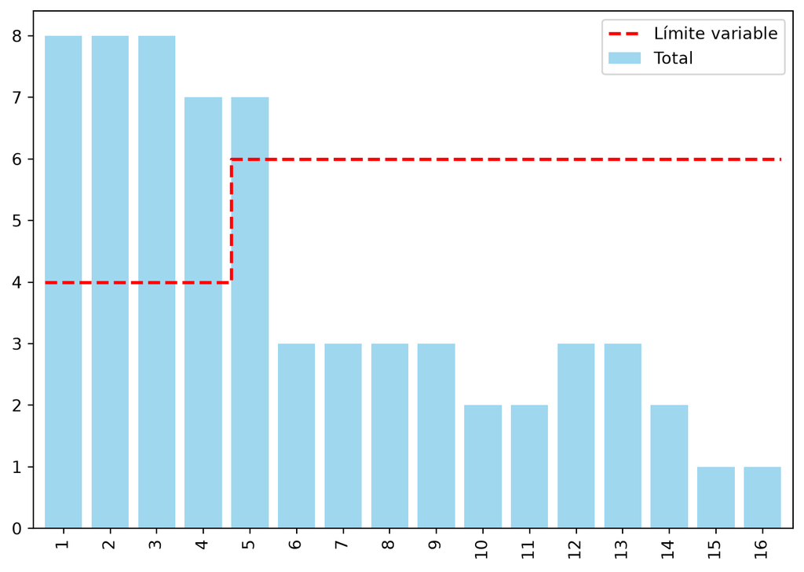

Figura 3: Diagrama de cargas con el límite de operarios

**Respuesta:** no se respeta: la carga supera el límite en las semanas 1, 2, 3, 4 y 5 (semana 1: 8 > 4; semana 2: 8 > 4; semana 3: 8 > 4; semana 4: 7 > 4; semana 5: 7 > 6); con todo en su inicio más temprano harían falta hasta 8 operarios.

## Apartado 2

2. Reprograme el proyecto con el algoritmo de asignación de Wiest-Levy para respetar el límite. ¿Qué actividades se desplazan y cuánto se alarga el proyecto?

El algoritmo de asignación (Wiest-Levy en la librería) recorre el calendario semana a semana y aplaza lo que no cabe; si no basta con consumir holguras, aplaza también actividades críticas y el proyecto se alarga. Las filas 💤 del Gantt marcan las esperas introducidas.

Regla del algoritmo: en cada semana se toman las actividades que el calendario vigente sitúa en ella y se ordenan así: primero las ya empezadas (no se interrumpen); después, menor holgura total (recalculada tras los aplazamientos anteriores) y, a igualdad, menor duración. Se admiten en ese orden mientras la suma de recursos no supere el límite; las que no caben se aplazan una semana (y con ellas sus sucesoras, si no tienen holgura). En la traza, *Total* es la demanda de esa semana antes de aplazar.

Traza semana a semana (qué se programa y qué se aplaza una semana):

Periodo: 1.

Periodo: 1. Total: 8. Se programan: [‘A’, ‘B’]

Periodo: 1. Se desplazan: [‘C’]

Periodo: 2.

Periodo: 2. Total: 8. Se programan: [‘A’, ‘B’]

Periodo: 2. Se desplazan: [‘C’]

Periodo: 3.

Periodo: 3. Total: 8. Se programan: [‘A’, ‘B’]

Periodo: 3. Se desplazan: [‘C’]

Periodo: 4.

Periodo: 4. Total: 7. Se programan: [‘B’]

Periodo: 4. Se desplazan: [‘C’]

Periodo: 5.

Periodo: 5. Total: 7. Se programan: [‘B’]

Periodo: 5. Se desplazan: [‘C’]

Periodo: 6.

Periodo: 6. Total: 7. Se programan: [‘B’]

Periodo: 6. Se desplazan: [‘C’]

Periodo: 7.

Periodo: 7. Total: 7. Se programan: [‘B’]

Periodo: 7. Se desplazan: [‘C’]

Periodo: 8.

Periodo: 8. Total: 7. Se programan: [‘B’]

Periodo: 8. Se desplazan: [‘C’]

Periodo: 9.

Periodo: 9. Total: 4. Se programan: [‘C’]

Periodo: 10.

Periodo: 10. Total: 4. Se programan: [‘C’]

Periodo: 11.

Periodo: 11. Total: 4. Se programan: [‘C’]

Periodo: 12.

Periodo: 12. Total: 4. Se programan: [‘C’]

Periodo: 13.

Periodo: 13. Total: 4. Se programan: [‘C’]

Periodo: 14.

Periodo: 14. Total: 3. Se programan: [‘D’]

Periodo: 15.

Periodo: 15. Total: 2. Se programan: [‘E’]

Periodo: 16.

Periodo: 16. Total: 2. Se programan: [‘G’, ‘F’]

Periodo: 17.

Periodo: 17. Total: 3. Se programan: [‘G’, ‘H’]

Periodo: 18.

Periodo: 18. Total: 3. Se programan: [‘G’, ‘H’]

Periodo: 19.

Periodo: 19. Total: 2. Se programan: [‘H’]

Periodo: 20.

Periodo: 20. Total: 1. Se programan: [‘I’]

Periodo: 21.

Periodo: 21. Total: 1. Se programan: [‘I’]

Por qué se aplaza cada actividad: en las semanas en que la demanda supera el límite, la tabla da el orden de prioridad (con su holgura, duración y operarios), las que entran y, para cada aplazada, la suma que no cabe.

Tabla 4: Semanas con conflicto en la asignación

| semana | límite | demanda | orden de prioridad (holgura, duración, recurso) | entran | se aplazan una semana (no caben) |
| --- | --- | --- | --- | --- | --- |
| 1 | 4 | 8 | B (H=0, d=8, 3) › C (H=3, d=5, 4) › A (H=7, d=3, 1) | A y B | C: 3 + 4 = 7 > 4 |
| 2 | 4 | 8 | B (en curso, 3) › A (en curso, 1) › C (H=2, d=5, 4) | A y B | C: 4 + 4 = 8 > 4 |
| 3 | 4 | 8 | B (en curso, 3) › A (en curso, 1) › C (H=1, d=5, 4) | A y B | C: 4 + 4 = 8 > 4 |
| 4 | 4 | 7 | B (en curso, 3) › C (H=0, d=5, 4) | B | C: 3 + 4 = 7 > 4 |
| 5 | 6 | 7 | B (en curso, 3) › C (H=0, d=5, 4) | B | C: 3 + 4 = 7 > 6 |
| 6 | 6 | 7 | B (en curso, 3) › C (H=0, d=5, 4) | B | C: 3 + 4 = 7 > 6 |
| 7 | 6 | 7 | B (en curso, 3) › C (H=0, d=5, 4) | B | C: 3 + 4 = 7 > 6 |
| 8 | 6 | 7 | B (en curso, 3) › C (H=0, d=5, 4) | B | C: 3 + 4 = 7 > 6 |

[figure not shown]

Figura 4: Diagrama de Gantt tras la asignación

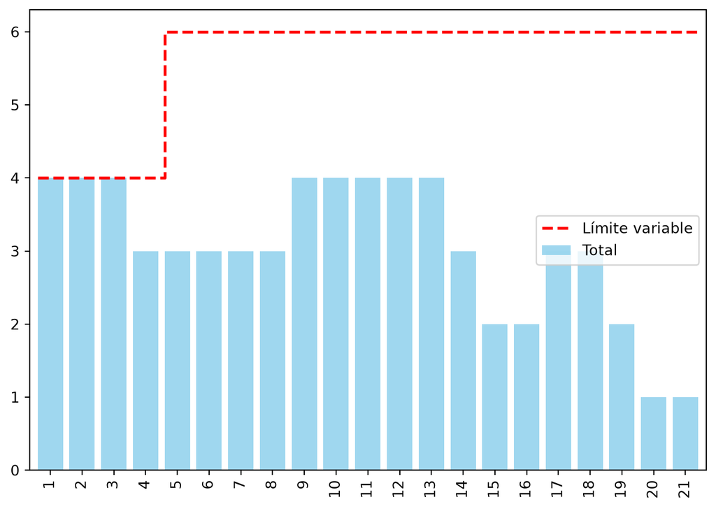

Figura 5: Diagrama de cargas tras la asignación

**Respuesta:** se desplazan C 8 semanas; el proyecto pasa de 16 a 21 semanas (se alarga 5 semanas) y el pico de operarios queda en 4.

## Apartado 3

3. ¿Y si se dispusiera de 4 operarios durante todo el proyecto? Compare las dos duraciones.

Periodo: 1.

Periodo: 1. Total: 8. Se programan: [‘A’, ‘B’]

Periodo: 1. Se desplazan: [‘C’]

Periodo: 2.

Periodo: 2. Total: 8. Se programan: [‘A’, ‘B’]

Periodo: 2. Se desplazan: [‘C’]

Periodo: 3.

Periodo: 3. Total: 8. Se programan: [‘A’, ‘B’]

Periodo: 3. Se desplazan: [‘C’]

Periodo: 4.

Periodo: 4. Total: 7. Se programan: [‘B’]

Periodo: 4. Se desplazan: [‘C’]

Periodo: 5.

Periodo: 5. Total: 7. Se programan: [‘B’]

Periodo: 5. Se desplazan: [‘C’]

Periodo: 6.

Periodo: 6. Total: 7. Se programan: [‘B’]

Periodo: 6. Se desplazan: [‘C’]

Periodo: 7.

Periodo: 7. Total: 7. Se programan: [‘B’]

Periodo: 7. Se desplazan: [‘C’]

Periodo: 8.

Periodo: 8. Total: 7. Se programan: [‘B’]

Periodo: 8. Se desplazan: [‘C’]

Periodo: 9.

Periodo: 9. Total: 4. Se programan: [‘C’]

Periodo: 10.

Periodo: 10. Total: 4. Se programan: [‘C’]

Periodo: 11.

Periodo: 11. Total: 4. Se programan: [‘C’]

Periodo: 12.

Periodo: 12. Total: 4. Se programan: [‘C’]

Periodo: 13.

Periodo: 13. Total: 4. Se programan: [‘C’]

Periodo: 14.

Periodo: 14. Total: 3. Se programan: [‘D’]

Periodo: 15.

Periodo: 15. Total: 2. Se programan: [‘E’]

Periodo: 16.

Periodo: 16. Total: 2. Se programan: [‘G’, ‘F’]

Periodo: 17.

Periodo: 17. Total: 3. Se programan: [‘G’, ‘H’]

Periodo: 18.

Periodo: 18. Total: 3. Se programan: [‘G’, ‘H’]

Periodo: 19.

Periodo: 19. Total: 2. Se programan: [‘H’]

Periodo: 20.

Periodo: 20. Total: 1. Se programan: [‘I’]

Periodo: 21.

Periodo: 21. Total: 1. Se programan: [‘I’]

Tabla 5: Semanas con conflicto con el límite constante

| semana | límite | demanda | orden de prioridad (holgura, duración, recurso) | entran | se aplazan una semana (no caben) |
| --- | --- | --- | --- | --- | --- |
| 1 | 4 | 8 | B (H=0, d=8, 3) › C (H=3, d=5, 4) › A (H=7, d=3, 1) | A y B | C: 3 + 4 = 7 > 4 |
| 2 | 4 | 8 | B (en curso, 3) › A (en curso, 1) › C (H=2, d=5, 4) | A y B | C: 4 + 4 = 8 > 4 |
| 3 | 4 | 8 | B (en curso, 3) › A (en curso, 1) › C (H=1, d=5, 4) | A y B | C: 4 + 4 = 8 > 4 |
| 4 | 4 | 7 | B (en curso, 3) › C (H=0, d=5, 4) | B | C: 3 + 4 = 7 > 4 |
| 5 | 4 | 7 | B (en curso, 3) › C (H=0, d=5, 4) | B | C: 3 + 4 = 7 > 4 |
| 6 | 4 | 7 | B (en curso, 3) › C (H=0, d=5, 4) | B | C: 3 + 4 = 7 > 4 |
| 7 | 4 | 7 | B (en curso, 3) › C (H=0, d=5, 4) | B | C: 3 + 4 = 7 > 4 |
| 8 | 4 | 7 | B (en curso, 3) › C (H=0, d=5, 4) | B | C: 3 + 4 = 7 > 4 |

[figure not shown]

Figura 6: Diagrama de Gantt con el límite constante

Esperas con el límite constante: C 8 semanas.

**Respuesta:** con 4 operarios durante todo el proyecto la duración sería de 21 semanas, frente a 21 con el refuerzo a 6 operarios a partir de la semana 5; la misma duración; en este proyecto el refuerzo no acorta el plazo.

## Apartado 4

4. Explique por qué la asignación puede alargar el proyecto y la nivelación nunca.

La nivelación sólo usa las holguras: desplaza actividades no críticas sin tocar el plazo, y si un desplazamiento alargara el proyecto no se prueba. La asignación impone una restricción dura (el límite de cada semana); si ni siquiera aplazando todas las actividades con holgura cabe la demanda, tiene que aplazar actividades críticas y el proyecto se alarga. **Respuesta:** aquí la asignación ha alargado el proyecto de 16 a 21 semanas porque en la semana 4 la actividad C, sin holgura, no cabía y hubo que aplazarla; la nivelación, por construcción, nunca cambia la duración.